# Baillon: Weather Forecasts

Quality Assurance - Respondi Data.

Hauke Roggenkamp https://github.com/Howquez (CLICCS)https://www.cliccs.uni-hamburg.de/  
2021-09-07

# Sample Size

We count 1277 people who initialized the survey. 53.2% of them failed to complete the survey which leaves us with 598 complete observations. The following visualization shows that most of the dropouts did not manage to read through the instructions. After having read them, few people dropped out.

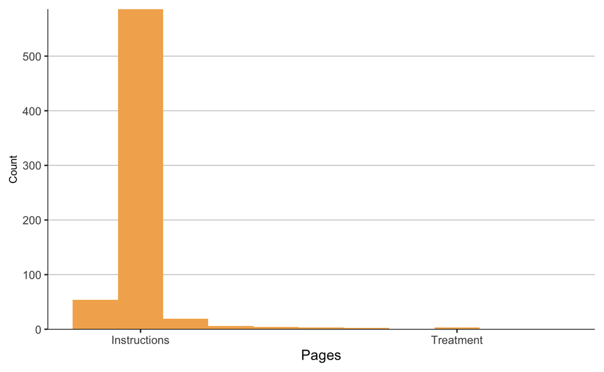

Figure 1: Dropouts by Page.

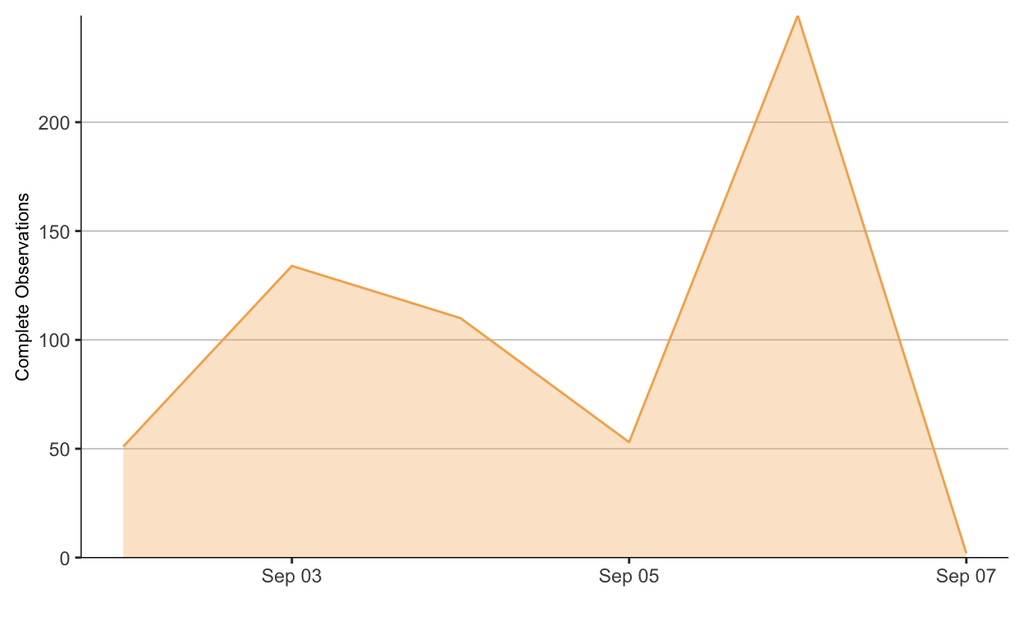

Figure 2: Complete Observations over Time.

482 participants state that they understood the instructions. 116 say that they did not.[^1]

# Time

The time spent on every decision looks as follows. Intuitively, the pattern makes sense as respondents learn from round 1 to 6. Round 7 exposes the respondents to the forecast, which needs some time to process.

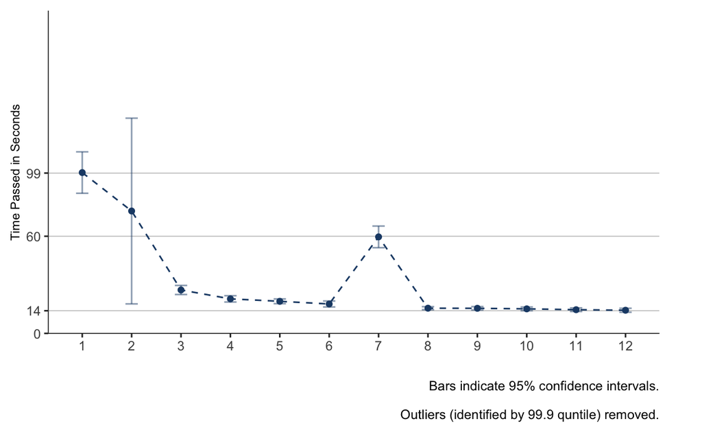

Figure 3: Average Time Spent for each Decision per Round.

The median time to complete the survey was 16 minutes.

# Variance

On an individual level, the data looks as follows.

| participant.label | participant.time_started_utc | ASEP | ACEP | AAI | AGII | treated |
| --- | --- | --- | --- | --- | --- | --- |
| ae5cb5802ca588f73a81e42242d1ae4c | 2021-09-02 10:56:24 | 0.50 | 0.4500000 | 0.0500000 | 1.15 | FALSE |
| 0e379132b6dab27b63921c941312840f | 2021-09-02 11:06:03 | 0.34 | 0.6700000 | -0.0100000 | 0.01 | FALSE |
| 0e379132b6dab27b63921c941312840f | 2021-09-02 11:06:03 | 0.34 | 0.6666667 | -0.0066667 | 0.02 | TRUE |
| ca48f818955f9a22b31d290dc2a28723 | 2021-09-02 11:22:18 | 0.40 | 0.4900000 | 0.1100000 | 0.73 | FALSE |
| ca48f818955f9a22b31d290dc2a28723 | 2021-09-02 11:22:18 | 0.40 | 0.7000000 | -0.1000000 | 0.10 | TRUE |

The reported indices stem from matching probabilities. To check whether respondents stated the matching probabilities diligently, we expect them to exhibit some variance at the individual level. It turns out that there are some people (32) who enter the same matching probability each and every time. The following graph visualizes each respondent’s standard deviation over all 12 rounds as a histogram:

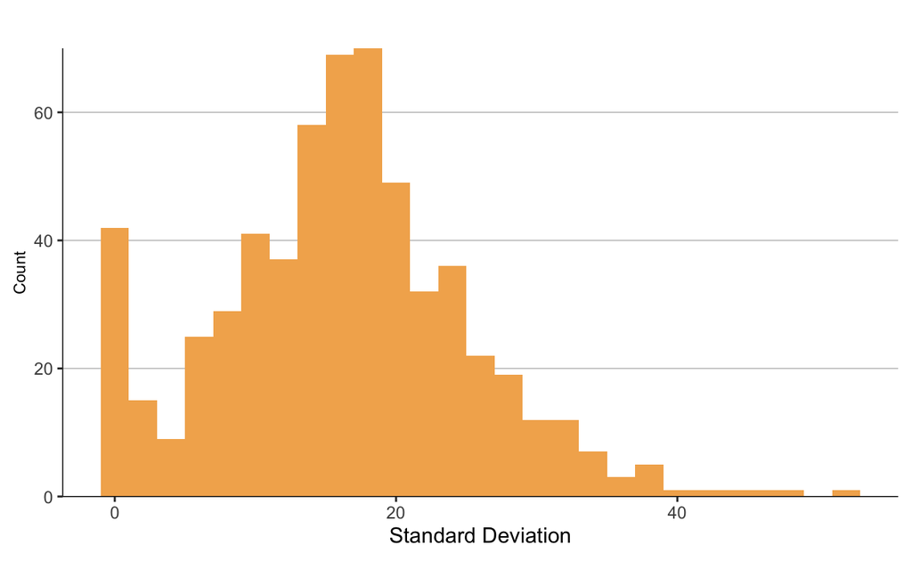

Figure 4: Histogram: Standard Deviation of individual Decisions (across all rounds)

# Treatments

Aggregating these information by treatment yields the following table (where `treated == TRUE` marks Baillon’s indices after participants have seen the forecast).

| treated | location | forecast | Ambiguity Aversion Index | a-insensitivity Index |
| --- | --- | --- | --- | --- |
| FALSE | Weiskirchen | interval | -0.0939881 | 0.7175000 |
| TRUE | Weiskirchen | interval | -0.0886364 | 0.7717273 |
| FALSE | Ilomantsi | both | -0.0667987 | 0.6732673 |
| TRUE | Ilomantsi | both | -0.0886139 | 0.6814851 |
| FALSE | Weiskirchen | both | -0.1000606 | 0.7574545 |
| TRUE | Weiskirchen | both | -0.0927160 | 0.6901852 |
| FALSE | Ilomantsi | interval | -0.0963462 | 0.7311538 |
| TRUE | Ilomantsi | interval | -0.0939934 | 0.6966337 |
| FALSE | Weiskirchen | best_guess | -0.0637847 | 0.7855208 |
| TRUE | Weiskirchen | best_guess | -0.1085069 | 0.8413542 |
| FALSE | Ilomantsi | best_guess | -0.0191860 | 0.7894186 |
| TRUE | Ilomantsi | best_guess | -0.0043775 | 0.7745783 |

The following graph illustrates sample size per treatment arms. Remember that Illomantsi is the surprising treatment group. Technically, the randomization process has not been changed and should work as before.

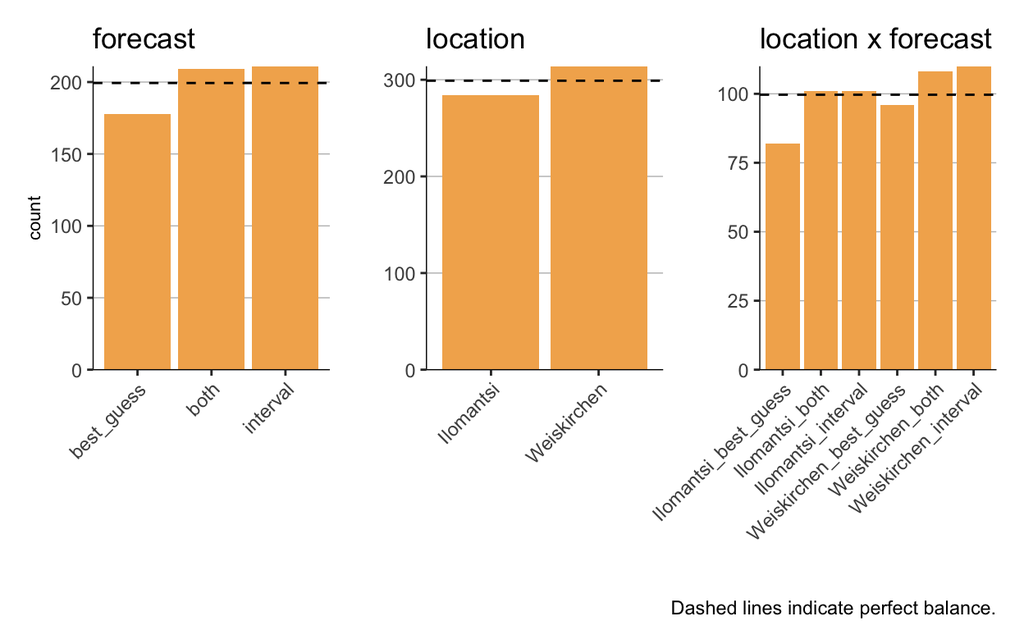

Figure 5: Sample Size by Treatment.

# Payoffs

| Participants | Total Bonus Payments | Average Bonus Payment |
| --- | --- | --- |
| 598 | 3500 | 5.85 |

# Sample Properties

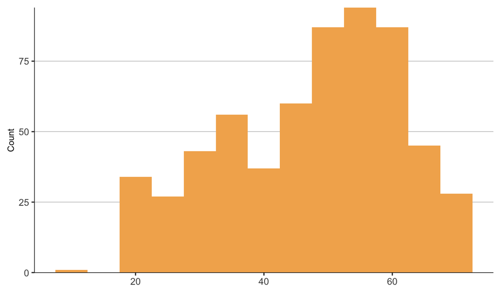

Figure 6: Histogram: Age Distribution.

[^1]: 11 stated that they did not understand the game at all.